# Final Project - Fatal Police Shootings

### By : Harrish Thasarathan, Tamilesh Balasuntharam and Shawn Yama

We chose to analyze a dataset called Fatal Police Shootings, 2015-Present. We found this dataset [here](https://www.kaggle.com/washingtonpost/police-shootings). This dataset contains 2142 rows and 14 columns. Every row represents a fatal police shooting and the columns include the details about the shooting that are unique to every person. We were compelled by this dataset because fatal police shootings are shown in media to be a significant problem in the United States of America. By analyzing this dataset we can figure out what type of people get fatally shot the most and make an informed decision about media representations in this age of fake news. Our hypothesis states that more minorities are being killed by cops, particularly African American males.

Importing essential packages as well as seaborn. Seaborn makes plotting data easier.

```python
import pandas as pd
import numpy as np
import matplotlib.pyplot as plt
%matplotlib inline
import seaborn as sns
sns.set(style="darkgrid")
```

## Curiosity and Exploration

We started off by analyzing the range of age of individuals fatally shot by police. We found the youngest and oldest age as well as the average age.

```python
df = pd.read_csv('database.csv')
df.shape
largest, smallest, mean = np.max(df['age']),np.min(df['age']),np.mean(df['age'])
print('max age:',largest, 'min age:', smallest , 'mean age:', mean)
```

```
max age: 86.0 min age: 6.0 mean age: 36.48451643639829
```

We found how many rows and columns there are in the dataset:

```python
df.shape
```

```
(2142, 14)
```

Here we printed out the beginning of the dataset to understand what variables are representing the data. For example now we know that the flee column is represented by a string. One can wrongly assume that it's boolean so it's good we made sure.

```python
df.head()
```

|  | id | name | date | manner_of_death | armed | age | gender | race | city | state | signs_of_mental_illness | threat_level | flee | body_camera |
| --- | --- | --- | --- | --- | --- | --- | --- | --- | --- | --- | --- | --- | --- | --- |
| 0 | 3 | Tim Elliot | 2015-01-02 | shot | gun | 53.0 | M | A | Shelton | WA | True | attack | Not fleeing | False |
| 1 | 4 | Lewis Lee Lembke | 2015-01-02 | shot | gun | 47.0 | M | W | Aloha | OR | False | attack | Not fleeing | False |
| 2 | 5 | John Paul Quintero | 2015-01-03 | shot and Tasered | unarmed | 23.0 | M | H | Wichita | KS | False | other | Not fleeing | False |
| 3 | 8 | Matthew Hoffman | 2015-01-04 | shot | toy weapon | 32.0 | M | W | San Francisco | CA | True | attack | Not fleeing | False |
| 4 | 9 | Michael Rodriguez | 2015-01-04 | shot | nail gun | 39.0 | M | H | Evans | CO | False | attack | Not fleeing | False |

Testing the data by plotting the different ways they are fleeing.

```
Text(0,0.5,'Number of instances per Flee entry')
```

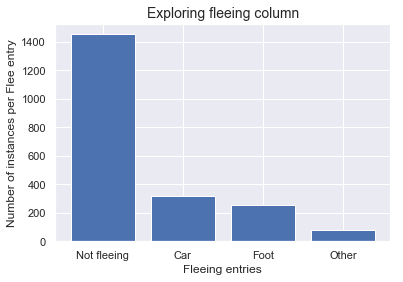

```python
fleeing_count = df['flee'].value_counts()
fleeing_count = pd.DataFrame(fleeing_count).reset_index()

plt.bar(fleeing_count['index'],fleeing_count['flee'])
plt.title("Exploring fleeing column",fontsize = 14)
plt.xlabel("Fleeing entries")
plt.ylabel("Number of instances per Flee entry")
```

Exploring the minmum ages of black and white people who got fatally shot.

```python
b_shot = df.loc[df['race']=='B']
w_shot = df.loc[df['race'] == 'W']

w_youngest = df.loc[df['age']== np.min(b_shot['age'])]
bl_youngest = df.loc[df['age'] == np.min(w_shot['age'])]
bl_youngest
```

|  | id | name | date | manner_of_death | armed | age | gender | race | city | state | signs_of_mental_illness | threat_level | flee | body_camera |
| --- | --- | --- | --- | --- | --- | --- | --- | --- | --- | --- | --- | --- | --- | --- |
| 830 | 980 | Jeremy Mardis | 2015-11-03 | shot | unarmed | 6.0 | M | W | Marksville | LA | False | other | Car | True |

```python
w_youngest
```

|  | id | name | date | manner_of_death | armed | age | gender | race | city | state | signs_of_mental_illness | threat_level | flee | body_camera |
| --- | --- | --- | --- | --- | --- | --- | --- | --- | --- | --- | --- | --- | --- | --- |
| 1678 | 1883 | Tyre King | 2016-09-14 | shot | toy weapon | 13.0 | M | B | Columbus | OH | False | other | Foot | False |

Checking the mean age per race for the different ways individuals died in the dataset.

```python
manner_of_death = df.groupby(['manner_of_death','race']).age.mean()
manner_of_death = pd.DataFrame(manner_of_death).reset_index()
manner_of_death
```

|  | manner_of_death | race | age |
| --- | --- | --- | --- |
| 0 | shot | A | 38.448276 |
| 1 | shot | B | 31.469185 |
| 2 | shot | H | 32.905045 |
| 3 | shot | N | 31.214286 |
| 4 | shot | O | 32.625000 |
| 5 | shot | W | 39.815240 |
| 6 | shot and Tasered | A | 29.000000 |
| 7 | shot and Tasered | B | 33.548387 |
| 8 | shot and Tasered | H | 33.708333 |
| 9 | shot and Tasered | O | 35.750000 |
| 10 | shot and Tasered | W | 38.896104 |

## Race and Age Analysis

At this point we will analyse the data in more detail, specifically in terms of race and age. We will do this by splitting the dataset into two dataframes. One dataframe contains people less than age 20 and another with people greater than age 20. These new dataframes will be analyzed in terms of race.

```python
age_under_20 = df.loc[df['age']<20]
age_over_20 = df.loc[df['age']>20]

age_over_20 = pd.DataFrame(age_over_20).reset_index()
age_under_20 = pd.DataFrame(age_under_20).reset_index()
```

Before we start analysing it we must consider a proportional sample of races. There is a great majority of Caucasians in America so it will appear as if white people are the most affected race if we don't even out these proportions. [Here](https://www.census.gov/quickfacts/fact/table/US/PST045217) is the link we used to find the race percentages in America to obtain a more accurate representation of trends against different races in America.

```python
#total race counts in USA calculated from total population from US census bureau
total_counts = np.array([46643800,197699990,58951700,18890600,4234100,11073800])

def getRaceCounts(y):
    countB=countW=countH=countO=countN=countA=countN = 0
    for x in y['race']:
        if x == 'B':
            countB += 1
        if x == 'W':
            countW += 1
        if x == 'H':
            countH += 1
        if x == 'O':
            countO += 1
        if x == 'N':
            countN +=1
        if x == 'A':
            countA +=1
    counts = np.array([countB, countW, countH, countA, countN, countO])
    return counts/total_counts*100

index = ['Black','White','Hispanic','Asian','Native','Other']
```

[figure not shown]

```python
#Graph unadjusted race counts
y20_unadjusted = getRaceCounts(age_under_20)/100 * total_counts #/100 *total counts to undo adjustment built into getRaceCounts function
y40_unadjusted = getRaceCounts(age_over_20)/100 * total_counts

explode = (0, 0.1, 0, 0, 0, 0)  # only "explode" the 2nd slice (i.e. 'Hogs')
a4_dims = (15.7,11.27)
fig1, ax1 = plt.subplots(figsize = a4_dims)
ax1.pie(y40_unadjusted, explode=explode, labels=index, autopct='%1.1f%%',shadow=True, startangle=90)
ax1.axis('equal')
plt.title('Unadjusted Fatalities Per Race Under the Age of 20', fontsize = 18)
plt.show()
```

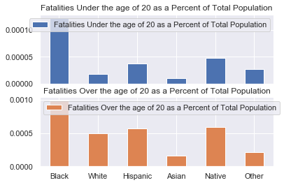

```python
y20_adjusted = getRaceCounts(age_under_20)
y40_adjusted = getRaceCounts(age_over_20)

compare_age_race = pd.DataFrame({'Fatalities Under the age of 20 as a Percent of Total Population':y20_adjusted,
                    'Fatalities Over the age of 20 as a Percent of Total Population':y40_adjusted},index = index)

axes = compare_age_race.plot.bar(rot = 0,subplots = True)
axes[1].legend(loc = 2);
```

The adjusted version shows that black people tend to be fatally shot by police more than white people. The high percentages of hispanic and natives compared to whites are surprising as well. Taking an equal sample of every race truly yields different results!

Now we will analyze people who are underage and possess a gun between the ages of 16 and 21. Here we are checking how many are armed and unarmed. Also we will analyze those who have a gun and are a threat. Our focus will be unarmed individuals since police should refrain from shooting an unarmed man.

```python
age21 = (df['age'] >= 16) & (df['age'] <= 21)
age21Unarmed = ((df['age'] >= 16) & (df['age'] <= 21) & (df['armed'] == 'unarmed'))
age21Gun = ((df['age'] >= 16) & (df['age'] <= 21) & (df['armed'] == 'gun'))
age21GunandThreat = ((df['age'] >= 16) & (df['age'] <= 21) & (df['armed'] == 'gun') & (df['threat_level'] == True))
```

```python
age21DataU = df.loc[age21Unarmed]
age21DataU
```

|  | id | name | date | manner_of_death | armed | age | gender | race | city | state | signs_of_mental_illness | threat_level | flee | body_camera |
| --- | --- | --- | --- | --- | --- | --- | --- | --- | --- | --- | --- | --- | --- | --- |
| 147 | 187 | Deven Guilford | 2015-02-28 | shot and Tasered | unarmed | 17.0 | M | W | Roxand Township | MI | False | attack | Not fleeing | True |
| 166 | 203 | Tony Robinson | 2015-03-06 | shot | unarmed | 19.0 | M | B | Madison | WI | False | attack | Foot | False |
| 206 | 295 | Jamison Childress | 2015-03-19 | shot | unarmed | 20.0 | M | W | Sumas | WA | True | attack | Not fleeing | False |
| 209 | 229 | Brandon Jones | 2015-03-19 | shot | unarmed | 18.0 | M | B | Cleveland | OH | False | attack | Not fleeing | False |
| 299 | 391 | William Chapman | 2015-04-22 | shot | unarmed | 18.0 | M | B | Portsmouth | VA | False | undetermined | Not fleeing | False |
| 306 | 409 | Hector Morejon | 2015-04-23 | shot | unarmed | 19.0 | M | H | Long Beach | CA | False | other | Not fleeing | False |
| 387 | 491 | Feras Morad | 2015-05-27 | shot and Tasered | unarmed | 20.0 | M | O | Long Beach | CA | False | other | Not fleeing | False |
| 396 | 500 | Ebin Lamont Proctor | 2015-05-30 | shot | unarmed | 19.0 | M | W | Cottonwood | AZ | False | attack | Foot | False |
| 479 | 592 | John Deming | 2015-07-05 | shot | unarmed | 19.0 | M | W | Pleasanton | CA | False | attack | Foot | False |
| 530 | 657 | Darrius Stewart | 2015-07-17 | shot | unarmed | 19.0 | M | B | Memphis | TN | False | attack | Foot | False |
| 586 | 711 | Christian Taylor | 2015-08-07 | shot | unarmed | 19.0 | M | B | Arlington | TX | False | other | Not fleeing | False |
| 717 | 850 | Steven McKenny | 2015-09-21 | shot and Tasered | unarmed | 21.0 | M | W | Paris | TX | False | attack | Not fleeing | False |
| 726 | 859 | Keith Harrison McLeod | 2015-09-23 | shot | unarmed | 19.0 | M | B | Reisterstown | MD | False | other | Foot | False |
| 732 | 866 | William Lemmon | 2015-09-25 | shot | unarmed | 21.0 | M | W | Akron | OH | False | undetermined | Other | False |
| 797 | 941 | Ryan Christopher Rodriguez | 2015-10-21 | shot | unarmed | 21.0 | M | H | West Goshen | CA | True | attack | Not fleeing | False |
| 812 | 956 | Kobvey Igbuhay | 2015-10-26 | shot | unarmed | 18.0 | M | O | Tampa | FL | False | attack | Foot | False |
| 1092 | 1247 | David Joseph | 2016-02-08 | shot | unarmed | 17.0 | M | B | Austin | TX | False | other | Not fleeing | False |
| 1110 | 1272 | Dyzhawn L. Perkins | 2016-02-13 | shot | unarmed | 19.0 | M | B | Arvonia | VA | False | attack | Not fleeing | False |
| 1147 | 1318 | Christopher J. Davis | 2016-02-24 | shot | unarmed | 21.0 | M | B | East Troy | WI | False | undetermined | Car | False |
| 1190 | 1358 | Jose Raul Cruz | 2016-03-13 | shot | unarmed | 16.0 | M | H | Addison | TX | False | undetermined | Car | False |
| 1467 | 1653 | Dylan Noble | 2016-06-25 | shot | unarmed | 19.0 | M | W | Fresno | CA | True | other | Car | True |
| 1546 | 1736 | Dalvin Hollins | 2016-07-27 | shot | unarmed | 19.0 | M | B | Tempe | AZ | True | attack | Foot | False |
| 1818 | 2028 | Kenton Kobza | 2016-11-08 | shot and Tasered | unarmed | 19.0 | M | W | Hays | KS | False | attack | Car | False |
| 2039 | 2275 | Steve Salgado | 2017-01-29 | shot | unarmed | 18.0 | M | H | Santa Ana | CA | False | undetermined | Foot | False |
| 2081 | 2325 | Ambroshia Fagre | 2017-02-10 | shot | unarmed | 18.0 | F | NaN | Vassalboro | ME | False | other | NaN | False |

Here we made a bar graph using the unproportionate values of those who are unarmed and got shot. The graph shows that black people are fatally injured the most. Once again we review the unadjusted data to reiterate how much of a difference adjusting values for percent population makes on overall trends.

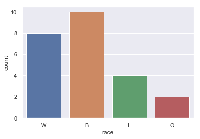

```python
sns.countplot(age21DataU['race']);
```

Next we will do the same thing but using proportionate values. This version of the graph shows that African Americans are fatally shot a lot more and Caucasians a lot less when compared to the previous graph when analyzing incidents with people under 21.

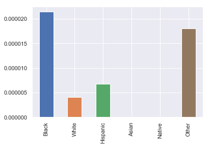

```python
race21CountU = getRaceCounts(age21DataU)
race21CountU_Series = pd.Series(race21CountU, index = index)
race21CountU_Series.plot.bar();
```

Reviewing data of underaged armed individuals fatally killed by police.

```python
age21DataA = df.loc[age21Gun]
age21DataA
```

|  | id | name | date | manner_of_death | armed | age | gender | race | city | state | signs_of_mental_illness | threat_level | flee | body_camera |
| --- | --- | --- | --- | --- | --- | --- | --- | --- | --- | --- | --- | --- | --- | --- |
| 5 | 11 | Kenneth Joe Brown | 2015-01-04 | shot | gun | 18.0 | M | W | Guthrie | OK | False | attack | Not fleeing | False |
| 39 | 74 | Terence Walker | 2015-01-17 | shot | gun | 21.0 | M | B | Muskogee | OK | False | attack | Foot | True |
| 48 | 90 | Isaac Holmes | 2015-01-21 | shot | gun | 19.0 | M | B | St. Louis | MO | False | attack | Not fleeing | False |
| 76 | 528 | Jacob Haglund | 2015-02-02 | shot | gun | 17.0 | M | W | Bay City | MI | False | attack | Not fleeing | False |
| 106 | 146 | Andres Lara-Rodriguez | 2015-02-13 | shot | gun | 21.0 | M | H | Kansas City | KS | False | attack | Car | False |
| 110 | 149 | Jason C. Hendrix | 2015-02-14 | shot | gun | 16.0 | M | W | Essex | MD | True | attack | Car | False |
| 136 | 176 | A'Donte Washington | 2015-02-23 | shot | gun | 16.0 | M | B | Millbrook | AL | False | attack | Not fleeing | False |
| 156 | 196 | Shaquille Barrow | 2015-03-02 | shot | gun | 20.0 | M | B | Joilet | IL | False | other | Foot | False |
| 197 | 290 | Eugene Smith | 2015-03-17 | shot | gun | 20.0 | M | W | Onalaska | TX | True | attack | Not fleeing | False |
| 205 | 265 | Kendre Alston | 2015-03-19 | shot | gun | 16.0 | M | B | Jacksonville | FL | False | attack | Car | False |
| 217 | 235 | Enoch Gaver | 2015-03-21 | shot | gun | 21.0 | M | W | Cottonwood | AZ | False | attack | Not fleeing | False |
| 252 | 296 | Justus Howell | 2015-04-04 | shot | gun | 17.0 | M | B | Zion | IL | False | attack | Foot | False |
| 287 | 380 | Jeffrey Kemp | 2015-04-17 | shot | gun | 18.0 | M | B | Chicago | IL | False | attack | Foot | False |
| 310 | 412 | Todd Jamal Dye | 2015-04-24 | shot | gun | 20.0 | M | B | Trinidad | CO | False | attack | Foot | True |
| 319 | 417 | Jared Johnson | 2015-04-28 | shot | gun | 21.0 | M | B | New Orleans | LA | False | attack | Not fleeing | True |
| 339 | 432 | David William Johnson | 2015-05-06 | shot | gun | 18.0 | M | W | Wake Forest | NC | False | attack | Car | False |
| 360 | 459 | Austin Goodner | 2015-05-17 | shot | gun | 18.0 | M | W | St. Petersburg | FL | True | attack | Not fleeing | False |
| 364 | 465 | David Gaines | 2015-05-19 | shot | gun | 17.0 | M | W | Grand Junction | CO | False | attack | Other | False |
| 405 | 509 | Miguel Martinez | 2015-06-03 | shot | gun | 18.0 | M | H | Ellis County | TX | True | attack | Car | False |
| 424 | 540 | Isiah Hampton | 2015-06-10 | shot | gun | 19.0 | M | B | Bronx | NY | False | attack | Not fleeing | False |
| 443 | 560 | Trepierre Hummons | 2015-06-19 | shot | gun | 21.0 | M | B | Cincinnati | OH | True | attack | Not fleeing | False |
| 451 | 576 | Tyrone Harris | 2015-06-22 | shot | gun | 20.0 | M | B | Pittsburgh | PA | False | attack | Car | False |
| 483 | 590 | Tyler Rogers | 2015-07-06 | shot | gun | 20.0 | M | W | Oklahoma City | OK | False | attack | Not fleeing | False |
| 488 | 608 | Marcellus Jamarcus Burley | 2015-07-07 | shot | gun | 18.0 | M | B | Houston | TX | False | attack | Not fleeing | False |
| 501 | 625 | Cyrus Hurtado | 2015-07-09 | shot | gun | 17.0 | M | W | Boulder Creek | CA | True | attack | Not fleeing | False |
| 505 | 630 | Freddie Blue | 2015-07-10 | shot | gun | 20.0 | M | B | Covington | GA | False | attack | Not fleeing | False |
| 513 | 629 | Frederick Farmer | 2015-07-13 | shot | gun | 20.0 | M | B | Stone Mountain | GA | False | attack | Not fleeing | False |
| 517 | 639 | Chacarion Avant | 2015-07-14 | shot | gun | 20.0 | M | B | Mascotte | FL | False | attack | Not fleeing | False |
| 573 | 698 | Joshua Malave | 2015-08-03 | shot | gun | 18.0 | M | W | Campbelltown | PA | False | attack | Foot | False |
| 581 | 706 | Keshawn Dominique Hargrove | 2015-08-05 | shot | gun | 20.0 | M | B | Richmond | VA | False | attack | Foot | False |
| ... | ... | ... | ... | ... | ... | ... | ... | ... | ... | ... | ... | ... | ... | ... |
| 1498 | 1681 | Anthony Nunez | 2016-07-04 | shot | gun | 18.0 | M | H | San Jose | CA | True | other | Not fleeing | False |
| 1499 | 1683 | Sidney Washington | 2016-07-04 | shot | gun | 21.0 | M | B | Washington | DC | False | attack | Not fleeing | False |
| 1541 | 1732 | Richard Risher | 2016-07-25 | shot | gun | 18.0 | M | B | Los Angeles | CA | False | attack | Foot | False |
| 1545 | 1735 | Devon Martes | 2016-07-27 | shot | gun | 17.0 | M | B | Metairie | LA | False | attack | Foot | False |
| 1599 | 1795 | Kenney Watkins | 2016-08-16 | shot | gun | 18.0 | M | B | Los Angeles | CA | False | other | Foot | False |
| 1641 | 1841 | Michael Ferguson | 2016-08-31 | shot | gun | 21.0 | M | W | Denver | CO | False | attack | Foot | False |
| 1644 | 1843 | Caleb J. Douglas | 2016-09-01 | shot | gun | 18.0 | M | W | Wichita | KS | False | other | Car | True |
| 1720 | 1931 | Jacquarius M. Robinson | 2016-09-30 | shot | gun | 20.0 | M | B | Columbus | OH | False | other | Foot | False |
| 1722 | 1925 | Carnell Snell | 2016-10-01 | shot | gun | 18.0 | M | B | Los Angeles | CA | False | undetermined | Foot | True |
| 1745 | 1951 | Kheyanev Littledog | 2016-10-10 | shot | gun | 19.0 | M | N | Midland | TX | False | other | NaN | False |
| 1762 | 1973 | Keegan Schweikle | 2016-10-17 | shot | gun | 17.0 | M | W | Benton | AR | True | attack | Foot | False |
| 1778 | 1989 | Aaron Marquis Ballard | 2016-10-24 | shot | gun | 19.0 | M | B | North St. Louis | MO | False | attack | Car | False |
| 1833 | 2041 | Daniel Laguna | 2016-11-13 | shot | gun | 21.0 | M | H | Oklahoma City | OK | False | attack | Not fleeing | False |
| 1849 | 2063 | Jacob C. Stevens | 2016-11-20 | shot | gun | 18.0 | M | W | Kansas City | MO | False | other | Foot | False |
| 1850 | 2060 | George Bush III | 2016-11-21 | shot | gun | 19.0 | M | B | St. Louis | MO | False | attack | Foot | False |
| 1908 | 2126 | Lavar Montray Douglas | 2016-12-13 | shot | gun | 18.0 | M | B | Baltimore | MD | False | attack | Not fleeing | False |
| 1930 | 2150 | Terrence Thomas | 2016-12-22 | shot | gun | 19.0 | M | B | Capitol Heights | MD | False | attack | Not fleeing | False |
| 1934 | 2158 | Daquan Antonio Westbrook | 2016-12-24 | shot | gun | 18.0 | M | B | Charlotte | NC | False | undetermined | Not fleeing | False |
| 1948 | 2176 | Jamal Rollins | 2016-12-30 | shot | gun | 21.0 | M | B | Miami | FL | False | other | Car | False |
| 1962 | 2190 | Joshua Martino | 2017-01-04 | shot | gun | 18.0 | M | H | Brooklyn | NY | False | attack | Foot | False |
| 1966 | 2194 | Luis Vargas | 2017-01-05 | shot | gun | 20.0 | M | H | Dinuba | CA | False | attack | Not fleeing | False |
| 1978 | 2206 | Davion Henderson | 2017-01-09 | shot | gun | 21.0 | M | B | St. Louis | MO | False | attack | Car | False |
| 1985 | 2224 | Jamison Christopher Anderson | 2017-01-12 | shot | gun | 20.0 | M | N | Vineland | MN | False | attack | Not fleeing | False |
| 2004 | 2243 | Marquis Thomas | 2017-01-18 | shot | gun | 19.0 | M | B | Gary | IN | False | attack | Car | False |
| 2026 | 2258 | Jose Efrain Rodriguez | 2017-01-24 | shot and Tasered | gun | 18.0 | M | H | Lancaster City | PA | False | attack | Not fleeing | False |
| 2037 | 2274 | Mi'Chance Dunlap-Gittens | 2017-01-28 | shot | gun | 17.0 | M | B | Des Moines | WA | False | attack | Not fleeing | False |
| 2068 | 2310 | Curtis Jamal Deal | 2017-02-07 | shot | gun | 18.0 | M | B | Baltimore | MD | False | other | Other | True |
| 2101 | 2346 | Kadeem Torres | 2017-02-16 | shot | gun | 17.0 | M | B | Brooklyn | NY | False | attack | Foot | False |
| 2103 | 2350 | Jimmy Briggs | 2017-02-16 | shot | gun | 21.0 | M | B | Gardena | CA | False | attack | Foot | False |
| 2141 | 2394 | Christopher Redding | 2017-02-28 | shot | gun | 20.0 | M | B | Orlando | FL | False | attack | Foot | False |

102 rows × 14 columns

Notice the below plot, in certain situations, even without adjustment of population percentages, minorities are the most prominent population affected by police shootings while armed

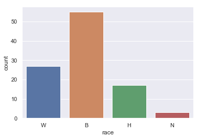

```python
#Without converting the calculation for population proportion
sns.countplot(age21DataA['race']);
```

Replotting with adjusted percentages to enforce the overwhelming presence of minority fatalities in the dataset. In addition we review trends relating race, age under 21, and threat level.

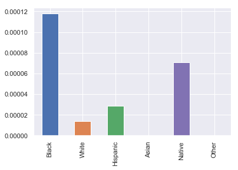

```python
#Converting to percent total population
race21CountA = getRaceCounts(age21DataA)
race21CountA_Series = pd.Series(race21CountA, index = index)
race21CountA_Series.plot.bar();
```

Once more minorities, specifically african americans, are the most heavily prevalent race when looking at fatal shootings among young adults. Caucasians and Asians on the other hand are the lease present race of young adults.

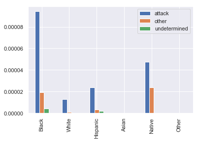

```python
#Data adjusted with pop
attack = age21DataA.loc[(age21DataA['threat_level'] == 'attack')]
other = age21DataA.loc[(age21DataA['threat_level'] == 'other')]
undetermindend = age21DataA.loc[(age21DataA['threat_level'] == 'undetermined')]
race21CountA_T_Series = pd.DataFrame({'attack': getRaceCounts(attack), 'other': getRaceCounts(other),
                                      'undetermined':getRaceCounts(undetermindend)}, index = index)
race21CountA_T_Series.plot.bar();
```

## Analysis of Incidents with Reported Mental Health Issues

Issues relating to the way police handle individuals with mental illness have also been expressed in the media and this dataset happens to have a column dedicated to "signs of mental illness". Although this is not a guarenteed diagnosis of an actual mental illness, it is still an opportunity to take a glimpse into the way police may handle such situations. In order to do so we isolate instances where signs of mental illness are labeled true and plot them against whether the individual was armed with a gun, something other than a gun, or compeltely unarmed. Situations may arise when police may use excessive force against an individual with a mental illness who is "armed" with something other than a gun when said individual may not have been dangerous to begin with.

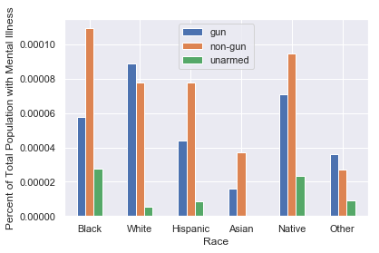

```python
#With whether individual was armed against race, issues with the mental illness column

mental = df.loc[(df['signs_of_mental_illness'] == True) & (df['armed'] != 'gun')]

mental_armed = df.loc[(df['signs_of_mental_illness'] == True) & (df['armed'] == 'gun')]

mental_unarmed = df.loc[(df['signs_of_mental_illness'] == True) & (df['armed'] == 'unarmed')]

doubleplot = pd.DataFrame({'gun': getRaceCounts(mental_armed), 'non-gun': getRaceCounts(mental), 'unarmed':getRaceCounts(mental_unarmed)},index = index)

axes = doubleplot.plot.bar(rot = 0)
axes.set_xlabel('Race')
axes.set_ylabel('Percent of Total Population with Mental Illness');
```

### Fatally Shot by Police While Unarmed

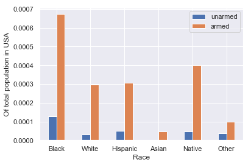

```python
unarmed = df.loc[df['armed'] == 'unarmed']
armed = df.loc[df['armed'] == 'gun']

armed_plot = pd.DataFrame({'unarmed':getRaceCounts(unarmed),'armed':getRaceCounts(armed)},index = index)
ax = armed_plot.plot.bar(rot = 0)
ax.set_xlabel('Race')
ax.set_ylabel('Of Total Population in USA');
```

### Mental Health and Age

```python
age65 = (df['age'] >= 65)
age65Data = df.loc[age65]
age65Data
```

|  | id | name | date | manner_of_death | armed | age | gender | race | city | state | signs_of_mental_illness | threat_level | flee | body_camera |
| --- | --- | --- | --- | --- | --- | --- | --- | --- | --- | --- | --- | --- | --- | --- |
| 19 | 38 | Jimmy Foreman | 2015-01-09 | shot | gun | 71.0 | M | W | England | AR | False | attack | Not fleeing | False |
| 29 | 52 | Talbot Schroeder | 2015-01-14 | shot | knife | 75.0 | M | W | Old Bridge | NJ | False | attack | Not fleeing | False |
| 30 | 54 | Robert Edwards | 2015-01-14 | shot | gun | 68.0 | M | W | Lake Jackson | TX | False | attack | Not fleeing | False |
| 43 | 83 | Carter Castle | 2015-01-18 | shot and Tasered | gun | 67.0 | M | W | Gunlock | KY | True | attack | Not fleeing | False |
| 61 | 324 | Raymond Kmetz | 2015-01-26 | shot | gun | 68.0 | M | W | New Hope | MN | True | attack | Not fleeing | False |
| 92 | 554 | James Allen | 2015-02-07 | shot | gun | 74.0 | M | B | Gastonia | NC | False | attack | Not fleeing | False |
| 127 | 255 | Douglas Harris | 2015-02-20 | shot | gun | 77.0 | M | B | Birmingham | AL | True | attack | Not fleeing | False |
| 273 | 358 | Donald Allen | 2015-04-11 | shot | gun | 66.0 | M | W | Sand Springs | OK | True | attack | Not fleeing | True |
| 275 | 357 | Richard Dale Weaver | 2015-04-12 | shot | machete | 83.0 | M | W | Oklahoma City | OK | True | other | Not fleeing | False |
| 284 | 369 | Stanley Watson | 2015-04-15 | shot | gun | 72.0 | M | W | Cañon City | CO | True | attack | Not fleeing | False |
| 315 | 406 | Albert Hanson | 2015-04-26 | shot | gun | 76.0 | M | W | Kings County | CA | False | attack | Not fleeing | False |
| 340 | 433 | Joseph Roy | 2015-05-07 | shot | knife | 72.0 | M | NaN | Lawrenceville | GA | True | other | Not fleeing | False |
| 419 | 526 | Richard Warolf | 2015-06-08 | shot | gun | 69.0 | M | W | Sun City | AZ | True | attack | Not fleeing | False |
| 426 | 542 | Raymond Phillips | 2015-06-11 | shot | gun | 86.0 | M | NaN | Columbia | TN | True | attack | Not fleeing | False |
| 499 | 623 | Robert Hammonds | 2015-07-09 | shot | gun | 68.0 | M | W | Phoenix | AZ | False | attack | Foot | False |
| 518 | 641 | Charles Crandall | 2015-07-14 | shot | gun | 76.0 | M | NaN | Southington | OH | False | attack | Not fleeing | False |
| 534 | 654 | Charles Edward Dewey | 2015-07-18 | shot | gun | 65.0 | M | W | Colby | KS | False | attack | Not fleeing | False |
| 574 | 699 | Franklin Short | 2015-08-03 | shot | gun | 71.0 | M | W | Powhatan County | VA | False | attack | Not fleeing | False |
| 598 | 724 | Robert Patrick Quinn | 2015-08-09 | shot | toy weapon | 77.0 | M | NaN | Pittston | PA | True | attack | Not fleeing | False |
| 664 | 797 | Charles Robert Shaw | 2015-09-01 | shot | gun | 76.0 | M | W | Twinsburg | OH | False | attack | Not fleeing | False |
| 696 | 825 | Clifford Butler | 2015-09-13 | shot | gun | 67.0 | M | B | McAlester | OK | True | attack | Not fleeing | False |
| 896 | 1038 | Ralph Aguilar | 2015-11-29 | shot | gun | 69.0 | M | H | Sun City | AZ | True | attack | Not fleeing | False |
| 910 | 1055 | Neil Scott Stretesky | 2015-12-03 | shot | gun | 66.0 | M | W | Big Springs | NE | False | attack | Not fleeing | False |
| 923 | 1069 | Christopher Higdon | 2015-12-09 | shot | gun | 66.0 | M | W | Leitchfield | KY | False | attack | Not fleeing | False |
| 1097 | 1254 | David Brian Evans | 2016-02-10 | shot | gun | 67.0 | M | W | Abingdon | MD | False | attack | Not fleeing | False |
| 1164 | 1338 | John Alan Chamberlain | 2016-03-04 | shot | undetermined | 66.0 | M | NaN | Sims | AR | False | undetermined | NaN | False |
| 1217 | 1395 | Ralph "Phil" Grenon | 2016-03-21 | shot and Tasered | knife | 76.0 | M | W | Burlington | VT | True | other | Not fleeing | True |
| 1250 | 1427 | Jesus Juarez | 2016-04-01 | shot | shovel | 65.0 | M | H | Lockhart | TX | True | undetermined | Not fleeing | False |
| 1256 | 1433 | David Mack | 2016-04-03 | shot | Taser | 69.0 | M | W | Eau Claire | WI | False | attack | Not fleeing | False |
| 1394 | 1574 | Robert Wickizer | 2016-05-30 | shot | gun | 70.0 | M | W | Tualatin | OR | False | attack | Not fleeing | False |
| 1418 | 1607 | Clifford Tucker | 2016-06-09 | shot | gun | 68.0 | M | W | Ishpeming Township | MI | True | attack | Not fleeing | True |
| 1431 | 1621 | Edward Acquisto | 2016-06-13 | shot | gun | 80.0 | M | H | Tiverton | RI | False | attack | Car | False |
| 1506 | 1696 | Thomas Vandemark | 2016-07-06 | shot | gun | 65.0 | M | W | Rush Springs | OK | False | other | Not fleeing | True |
| 1564 | 1753 | Kenneth Eugene Bonanno | 2016-08-01 | shot | gun | 67.0 | M | W | Stafford | VA | False | attack | Not fleeing | False |
| 1572 | 1761 | E.J. Walters | 2016-08-03 | shot | gun | 69.0 | M | W | Scott County | VA | False | other | Car | False |
| 1579 | 1833 | James W. Jennings | 2016-08-08 | shot | gun | 69.0 | M | W | Little Mountain | SC | True | attack | Not fleeing | False |
| 1618 | 1803 | Pedro Montanez | 2016-08-20 | shot | knife | 71.0 | M | H | Indio | CA | False | other | Not fleeing | True |
| 1631 | 1822 | Darrel Hetrick | 2016-08-27 | shot | gun | 82.0 | M | W | Morgantown | WV | False | attack | Not fleeing | True |
| 1660 | 1863 | Bernard Cottrell | 2016-09-06 | shot | gun | 65.0 | M | NaN | Spencer | WV | True | attack | Car | False |
| 1662 | 1865 | Larry Grant Whitehead | 2016-09-06 | shot | gun | 70.0 | M | W | Gray | TN | False | other | Not fleeing | True |
| 1672 | 1877 | Dennis Claude Stanley | 2016-09-10 | shot | toy weapon | 69.0 | M | W | Montcalm | WV | True | other | Not fleeing | True |
| 1675 | 1880 | Eugene Craig | 2016-09-12 | shot | gun | 86.0 | M | NaN | Saratoga | CA | False | other | Not fleeing | False |
| 1681 | 1886 | Joseph Allen Schlosser | 2016-09-15 | shot | gun | 69.0 | M | W | Weeki Wachi | FL | True | other | Not fleeing | False |
| 1765 | 1975 | Deborah Danner | 2016-10-18 | shot | baseball bat | 66.0 | F | B | Bronx | NY | True | attack | Not fleeing | False |
| 1798 | 2008 | Henry Simpson | 2016-11-01 | shot | gun | 76.0 | M | W | Carson City | NV | False | other | Not fleeing | False |
| 1878 | 2095 | Quinton Phillips | 2016-12-01 | shot | gun | 83.0 | M | W | Dover | AR | False | attack | Not fleeing | False |
| 1905 | 2114 | Francisco Serna | 2016-12-12 | shot | unarmed | 73.0 | M | H | Bakersfield | CA | False | undetermined | Not fleeing | False |
| 1917 | 2136 | Ronald Roy Massengale | 2016-12-18 | shot | gun | 72.0 | M | W | Tulsa | OK | True | attack | Not fleeing | False |
| 1943 | 2170 | Judy Boardman | 2016-12-27 | shot | gun | 71.0 | F | W | Pearland | TX | False | attack | Not fleeing | False |
| 2058 | 2288 | Johnnie J. Harris | 2017-02-04 | shot | gun | 68.0 | M | B | Kansas City | MO | False | attack | Not fleeing | False |
| 2137 | 2382 | James Leroy Marker | 2017-02-26 | shot | gun | 66.0 | M | W | Floral City | FL | False | other | Car | False |

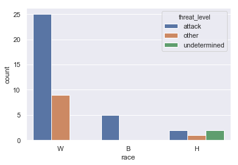

```python
sns.countplot(age65Data['race'], hue= age65Data['threat_level']);
```

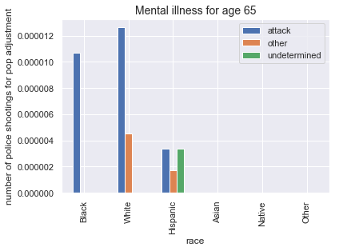

```python
#Data adjusted with pop
attack65 = age65Data.loc[(age65Data['threat_level'] == 'attack')]
other65 = age65Data.loc[(age65Data['threat_level'] == 'other')]
undetermindend65 = age65Data.loc[(age65Data['threat_level'] == 'undetermined')]
race65CountT_DF = pd.DataFrame({'attack': getRaceCounts(attack65), 'other': getRaceCounts(other65),
                                      'undetermined':getRaceCounts(undetermindend65)}, index = index)
race65CountT_DF.plot.bar();
plt.title('Mental illness for age 65',fontsize = 14)
plt.ylabel('number of police shootings for pop adjustment');
plt.xlabel('race');
```

```python
npage65racearray = np.array(age65Data.race.value_counts())
npage65threatarray = np.array(age65Data.threat_level.value_counts())
```

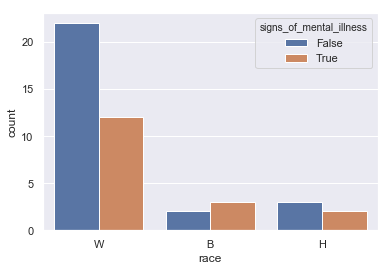

```python
sns.countplot(age65Data['race'], hue = age65Data['signs_of_mental_illness']);
```

## Body Camera and Time Trend Analysis

Body Cameras were initially introduced in 2013 and were said to be widely used by 95% of major police forces by 2015 according to the article [here](https://assets.bwbx.io/documents/users/iqjWHBFdfxIU/rvnT.EAJQwK4/v0). We wish to investigate this further. Are body cameras really used in these instances as is reported by police?

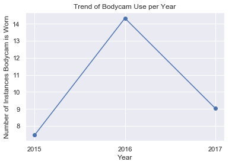

```python
def dateSplit(df):
    yearl = []
    monthl = []
    dayl = []
    for x in df['date']:
        year,month,day = x.split("-")
        yearl.append(year)
        monthl.append(month)
        dayl.append(day)

    bdcount2015 = 0
    bdcount2016 = 0
    bdcount2017 = 0

    for x in yearl:
        if x == '2015':
            bdcount2015 += 1
        if x == '2016':
            bdcount2016 += 1
        if x == '2017':
            bdcount2017 += 1
#        if x == '2018':
#            bdcount2018 += 1
    return [bdcount2015, bdcount2016, bdcount2017]

bd = df.loc[df['body_camera'] == True]
bd = bd.sort_values(by = ['date']) #How many instances per year where bodycam is true

by_date = df.sort_values(by = ['date'])
acc = np.array(dateSplit(by_date),dtype = np.float) #How many instances per year in total

bodycam_per_year = np.array(dateSplit(bd),dtype = np.float)

div_compare = bodycam_per_year/acc * 100 #percent of instances where bodycam is true plot against year
x = ['2015', '2016','2017']
bdf = pd.DataFrame({'year':x, 'counts':div_compare})
plt.plot('year', 'counts', data = bdf, linestyle='-', marker='o')
plt.title('Trend of Bodycam Use per Year')
plt.xlabel('Year')
plt.ylabel('Number of Instances Bodycam is Worn');
```

For the connected scatter plot above, we seperated, sorted, and counted each fatal incident by year taking into consideration the small amount of entries in 2017 (likely due to this dataset being published in 2017 itself) by finding a percentage for incidents where body cameras were used against total incidents for that year. Evidently this dataset shows the claims made in the aformentioned article are not completely true. The trend is as expected with the increase in average use between 2015 and 2016 and an unexplained significant decline in use for the entries of 2017.

## Analysis of Incident Areas by State and City

Finally we checked which cities have the most fatal police shootings. This is represented by a line graph. Los Angeles appears to be the most dangerous along with Houston, Pheonix and Chicago. The rest of the cities are definitely less dangerous.

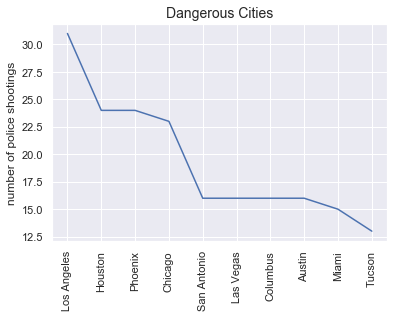

```python
group_city = df['city'].value_counts()
group_city = pd.DataFrame(group_city).reset_index()
group_city = group_city.head(10)
cities = group_city['index']
counts = np.array(group_city['city'])
plt.plot(cities, counts,linestyle = '-')
plt.xticks(rotation = 90);
plt.title('Dangerous Cities',fontsize = 14)
plt.ylabel('number of police shootings');
```

The most dangerous states where the most police shooting occur happend at California, Texas and Florida while the states with the least amount of police shootings are Vermont, North Dakota and Rhode Island

```
Text(0.5,0,'States')
```

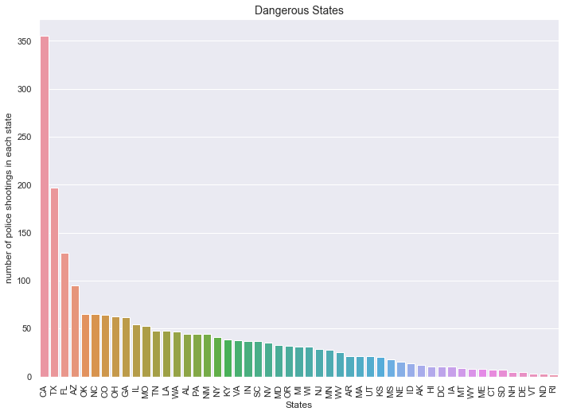

```python
a4_dims = (11.7, 8.27)
fig, ax = plt.subplots(figsize = a4_dims)
stateplot = sns.barplot(x = df.state.value_counts().index, y = df.state.value_counts())
stateplot.set_xticklabels(stateplot.get_xticklabels(),rotation=90);
plt.title('Dangerous States',fontsize = 14)
plt.ylabel('number of police shootings in each state');
plt.xlabel('States')
```